# Zerene 2018 differential expression 1

Fernando Rodriguez

June 22, 2018

This report provides the results of a series of differential expression analysis performed on the data set of RNA-seq reads from developing wing discs in Zerene cesonia. The pipeline used for obtainign the data is shown below

- Reads correction: After-QC v0.9.3
- Reads filtering and triming: Trimomatic v0.36
- Individual Transcriptome assemblies: Spades 3.10.1
- Consensus transcriptome assembly: Evidential Gene
- Transcriptome filtering: Blast, transrate, Bowtie2
- Reads mapped back to transcritpome: Bowtie2
- Gene expression estimation: RSEM

For this analysis, the libraries that did not show support of quality in the exploratory analysis were filtered out to reduce the efect of artifacts in the statistic estimations.

## Differential expression between Sexes

The tests below, compare expression between males and females across development in two ways: 1) Including the complit developmental timeline and 2) comparing expression on individual stages.

```r
# Differential day_1ression with DEseq ..............................

deseq_exp   <- DESeq_de(ex_data = edata, ph_data = pdata, var = sex)
deseq_larva <- DESeq_de(ex_data = edata, stage = '5th_instar', ph_data = pdata, var = sex)
deseq_day_1 <- DESeq_de(ex_data = edata, stage = 'Day_1', ph_data = pdata, var = sex)
deseq_day_2 <- DESeq_de(ex_data = edata, stage = 'Day_2', ph_data = pdata, var = sex)
deseq_day_3 <- DESeq_de(ex_data = edata, stage = 'Day_3', ph_data = pdata, var = sex)
deseq_day_4 <- DESeq_de(ex_data = edata, stage = 'Day_4', ph_data = pdata, var = sex)
deseq_day_5 <- DESeq_de(ex_data = edata, stage = 'Day_5', ph_data = pdata, var = sex)
```

### Differentially expressed genes across development

The graph below shows the results of differential expression between all males and females across development. The clusters at the top of the graph semm to group together the transcripts that are highly expressed in females across wing development. the heatmap do not show a cluster that reflect the oposit pattern, that is genes that are only expressed in males. A second cluster of interest ( bottom ) groups together genes that are only expressed in late development (day 5 and 6).

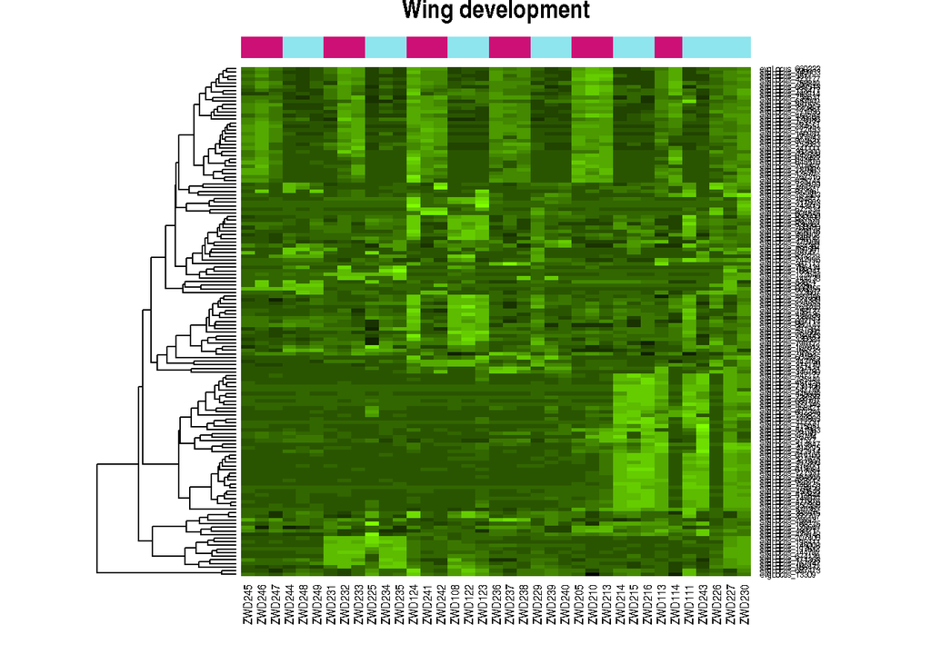

```r
title_key <- data.frame(name = 'Wing development', group = 'deseq_exp')
row.names(title_key) = c('deseq_exp')

Plot_top_diff('deseq_exp', prot_key, title_key)
```

### Differential expression within developmental stages

The graphs below show the results of differential expression within developmental stages. Larva 5th instar, pupa Day 3, and pupa Day 4, reflect consistent results among biological replicates all of them containing clusters of up and down regulated genes for males. In contrast, the remaining stages have at least one library that is not consistent with the expression patterns of the group:

**Day 1:** Library ZWD225 contains a subset of genes that are higly expressed and have no expression in any other library in the experiment. an exploration of the annotation of these genes shows that many of them are properly assembled transctipts that serve functions of Pupa formation and schlerotization. this suggests that this library was prepared from an individual that had not finished the pupal proteins synthesis.

**Day 2:** Library ZWD124 does not match the expression profile of the other two replicates in its group. No factors have been assigned to this disconcordancy yet.

**Day 5:** Most of the genes that were found to be differentially expressed in this group come from genes that are highly expressed only in library ZWD113. this subset of transcripts has not been explored.

It is worth noting that the libraries mentioned above fall fat away from their correspondent clusters in the PCA analyisi from the previous exploration.

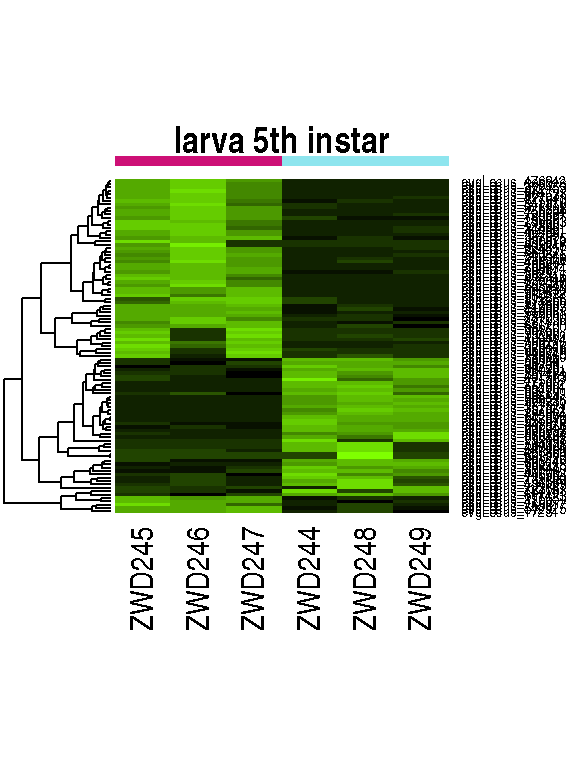

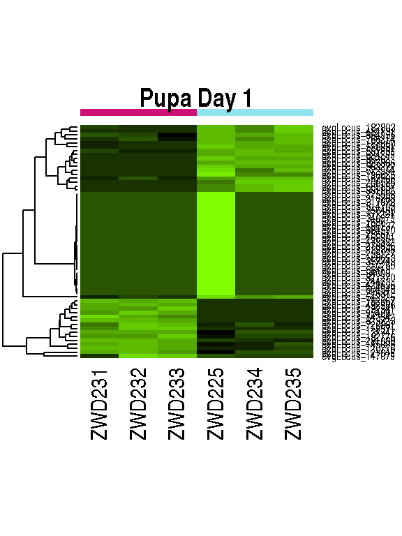

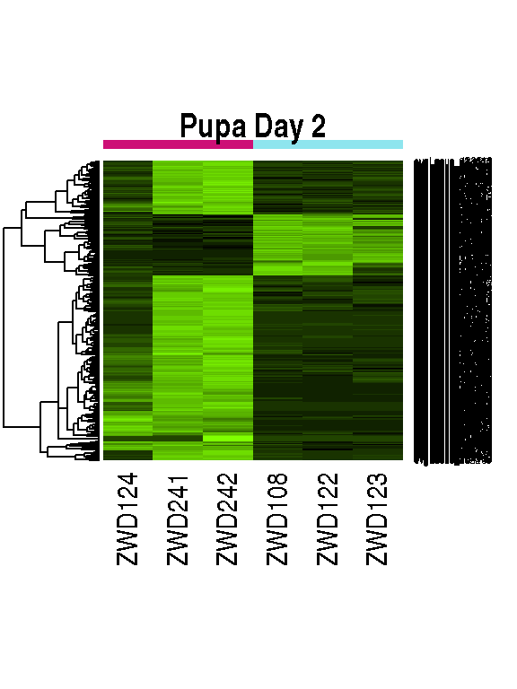

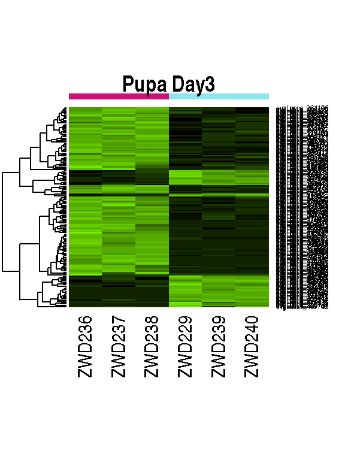

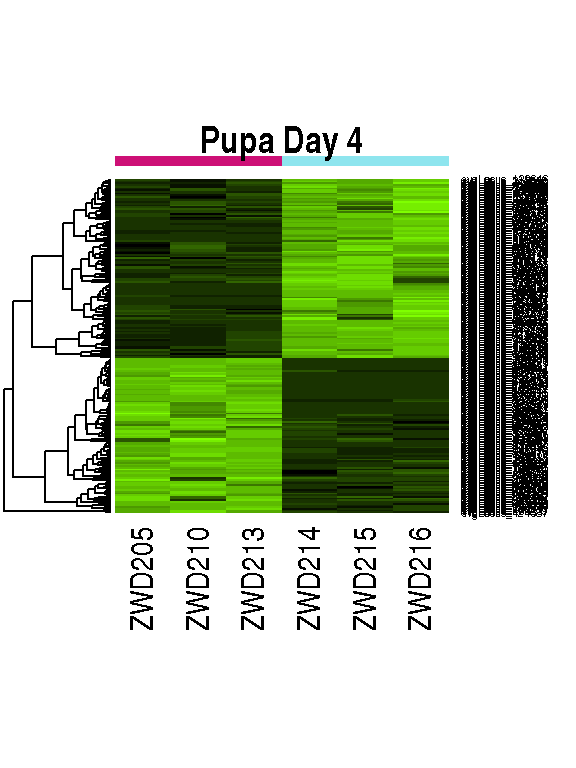

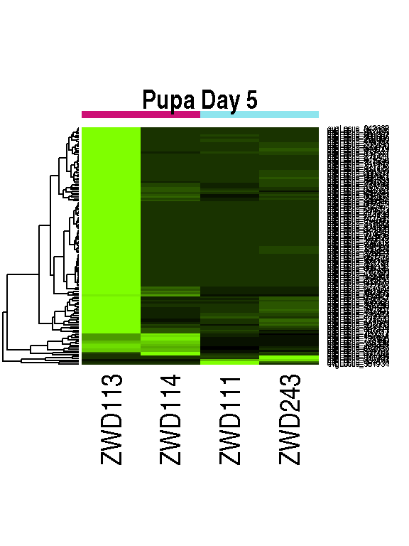

```r
# Extract differentially day_expressed genes on each group and plot .....................

my_groups <- c('deseq_larva','deseq_day_1','deseq_day_2','deseq_day_3',
              'deseq_day_4','deseq_day_5')

title_key <- data.frame(name = c('larva 5th instar',
                               'Pupa Day 1', 'Pupa Day 2', 'Pupa Day3',
                               'Pupa Day 4', 'Pupa Day 5'),
                       group = my_groups)

row.names(title_key)  <- title_key$group


for (grp in my_groups) {Plot_top_diff(grp, prot_key, title_key)}
```